# RStudio Server Pro @ Penn State

## Purpose

This document describes how to log-on and use Penn State’s RStudio Server instance from a web browser.

## Prerequisites

1. A Penn State [Access Account](http://www.identity.psu.edu/services/authentication-services/access-accounts/) user ID (e.g. rog1).
2. A web browser.
3. A computer that is connected to the Penn State network via [PSU wifi](http://wireless.psu.edu/wireless.html), or a physical network connection, or a connection to Penn State’s network via a [Virtual Private Network (VPN)](http://kb.its.psu.edu/article/891) application like Cisco AnyConnect.

## Procedure

1. Connect to the Penn State network (wifi ssid: psu).
2. Start your web browser.
3. Connect to https://lxclusterapps.tlt.psu.edu:8787 or to https://lxclusterapps-bygone.tlt.psu.edu:8788
   - You should see the following login page:

[figure not shown]

RStudio Server Pro login window

```r
knitr::include_graphics("../img/rstudio-login.jpg")
```

4. Enter your PSU access ID (e.g., rog1) in the `Username` field (Do **not** add `@psu.edu`), and enter your PSU password in the `Password` field. The use of a password manager like LastPass, 1Password, or DashLane is highly recommended.
5. Hit the `Sign In` button or press return on your keyboard. You should see an RStudio window that looks very much like this one.

[figure not shown]

```r
knitr::include_graphics("../img/rstudio-server-startup.jpg")
```

You are now ready to use RStudio Server!

## RStudio Server and PASS space

The RStudio Server application uses your PASS space for file storage.

To access your PASS space and upload files to it (like data),

1. Visit https://webfiles.psu.edu/. You will see a login window like this:

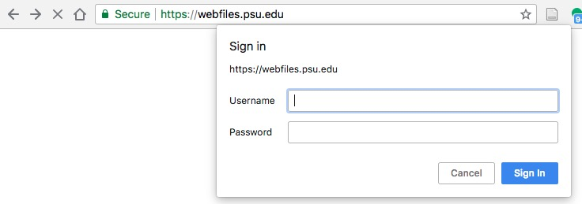

```r
knitr::include_graphics("../img/webfiles.psu.edu-login.jpg")
```

2. Enter your Penn State Access ID (e.g. rog1) and password. You should see the WebFiles interface:

[figure not shown]

```r
knitr::include_graphics("../img/webfiles-window.jpg")
```

3. Click on the `PASS Personal (X)` text or the `+` icon in the left panel. This will open a window on the right that shows the contents of your PASS space.
4. You may create new folders, upload, and download files using the WebFiles application.
5. Press the `logout` button in the upper right to logout when you are finished.